# Relief Over Identity: What Resolves Student Loan Complaints?

# Project 1

## 1.1 Introduction

The U.S. private student loan market carries over $130 billion in outstanding debt, yet relatively little is known about how servicer conduct shapes consumer outcomes when things go wrong. This paper asks whether institution type — specialist servicers versus traditional banks — affects the rate at which consumers dispute complaint resolutions, and whether resolution strategy mediates that relationship. Using 12,732 CFPB complaints filed between 2012 and 2016, merged with hand-collected firm characteristics, we find that relief — not institution type — is the primary driver of consumer dispute outcomes.

The student debt crisis has attracted substantial academic attention. Mueller and Yannelis (2019) document that loan defaults rose sharply after the Great Recession, while Looney and Yannelis (2022) show that credit expansion to high-default institutions explains most of the time-series variation in aggregate default rates. Yannelis and Tracey (2022) survey the literature and find that outcomes are highly heterogeneous, concentrated among for-profit institution attendees. Against this backdrop of widespread distress, how servicers respond to individual complaints takes on heightened importance.

The market structure distinction between specialists and banks is central to our design. Buchak et al. (2018) document that non-bank intermediaries grew rapidly due to regulatory advantages, and Eaton, Howell and Yannelis (2020) show that investor incentives in non-bank settings can diverge sharply from consumer interests. Whether this translates into systematically worse complaint outcomes for specialist-serviced borrowers is an open empirical question that motivates our research design.

The mechanism we test — relief as the operative channel — is grounded in two literatures. Agarwal et al. (2017) show that servicer-level heterogeneity in willingness to provide relief, not just program eligibility, determined household outcomes under HAMP. Di Maggio, Kalda and Yao (2020) exploit quasi-random private student debt discharge to show that tangible financial relief produces large improvements in borrower credit and labor outcomes while communication alone does not. Mueller and Yannelis (2022) confirm in a field experiment at Navient that reducing friction in repayment modification access sharply reduces delinquencies. Together, these papers establish that substantive help — not institutional identity — drives borrower outcomes.

The enforcement environment provides additional cross-firm variation. Kleymenova and Sandor find that CFPB complaint disclosure disciplines institutions by enabling competitive entry into markets where incumbents perform poorly. Piskorski, Seru and Vig (2010) further show that securitization frictions reduce servicer renegotiation rates — a structurally parallel finding to our result that incentive and organizational differences shape relief deployment.

This paper makes three contributions. First, we provide complaint-level evidence on dispute rate determinants using the CFPB database merged with hand-collected firm characteristics. Second, we let the data adjudicate between institution type and resolution strategy rather than imposing firm type as the primary variable. Third, we show that enforcement history moderates relief effectiveness. Our main finding: financial relief reduces dispute probability by ~11 pp (p < 0.001), stable across all specifications, while institution type is never significant.

## 1.2 Data Loading

#### 1.2.1 Data Sources and Sample Construction

The primary data source is the CFPB Consumer Complaint Database, restricted to "Student loan" complaints filed between March 2012 and April 2016. The CFPB database contains complaints against over 200 student loan servicers, but hand-collecting firm-level characteristics for all of them is infeasible. We therefore restrict the sample to the top 10 banks and top 10 specialists by student loan portfolio size, as determined by FDIC Call Reports for commercial banks and Federal Student Aid (FSA) Servicer Volume Reports for specialist servicers. These 20 firms dominate the private student loan market and account for about 80% of complaint volume during this period. Complaints with incomplete responses — coded as "In progress" or "Untimely response" — are excluded, yielding a final sample of 12,732 complaints across 20 firms.

Firm-level characteristics are hand-collected from three external sources. Total assets are drawn from 2014 SEC 10-K filings and cross-referenced with FDIC Call Reports; we use log assets in all specifications to reduce the influence of outliers. Institution type (specialist servicer vs. traditional bank) is determined by organizational structure as reported in FDIC and FSA disclosures. Enforcement history is compiled from the CFPB Enforcement Database and Department of Justice press releases, capturing major settlements and compliance actions against each firm between 2012 and 2016. From the CFPB complaint records, we construct the outcome variable (Disputed: 1 if the consumer filed a formal dispute, 0 otherwise), the mediator (Financial Relief: 1 if the firm provided monetary or non-monetary redress), and controls for issue type (loan servicing vs. inability to repay) and submission channel (web, referral, or other).

### 1.2.2 Variable Definitions & Research Design

**Variable Description**

The research framework employs a mediation model to analyze how institutional structures influence consumer outcomes through different resolution strategies.

**Primary Variables**

- Outcome Variable ($Y$): Dispute_Rate binary indicator representing whether the consumer disputed the company's response. A value of 1 indicates a dispute was filed, while 0 indicates the resolution was accepted without a formal dispute.
- Independent Variable ($X$): Is_Specialist dummy variable identifying the institution type. Specialized student loan servicers are assigned a value of 1, while traditional commercial banks are assigned a value of 0.
- Mediator Variable ($Z$): Response_Type Categorizes the firm’s resolution strategy into two primary types:Relief: Instances where the firm provided monetary or non-monetary redress to the consumer.Explanation: Instances where the firm provided only a standard explanation without offering tangible relief.

**Control Variables**

- Assets ($B): The total student loan portfolio managed or held by the institution in 2014, used to control for firm scale and market power.
- Has_Enforcement: A binary variable indicating whether the institution was subject to major regulatory enforcement actions by the CFPB or DOJ between 2012 and 2016.
- Issue_Type: Dummies for specific complaint categories (e.g., "Servicing" vs. "Inability to Repay") to account for variations in the severity of the consumer's underlying problem.
- Submission_Group: Controls for the complaint channel (Web, Referral, or Other) to mitigate potential selection bias in consumer behavior.

### 1.2.3 Cleaning the Original Data Set

```python
import pandas as pd

# Load the raw dataset
df_raw = pd.read_csv('consumer_complaints.csv', low_memory=False)

# Extract only student loan complaints for analysis
df = df_raw[df_raw['product'] == 'Student loan']

#Filter Data: Remove incomplete or untimely responses
df = df[~df['company_response_to_consumer'].isin(['In progress', 'Untimely response'])].copy()

#Standardize Issues: Merge similar issue categories
issue_mapping = {
    'Repaying your loan': 'Dealing with my lender or servicer',
    'Problems when you are unable to pay': "Can't repay my loan"
}
df['issue'] = df['issue'].replace(issue_mapping)

#Simplify Responses: Group responses into 'Relief', 'Explanation', or 'Other'
def simplify_response(response):
    if response == 'Closed with explanation':
        return 'Explanation'
    elif response in ['Closed with monetary relief', 'Closed with non-monetary relief', 'Closed with relief']:
        return 'Relief'
    else:
        return 'Other'

df['company_response_to_consumer'] = df['company_response_to_consumer'].apply(simplify_response)

#Binary Encoding: Convert outcome variable to 0/1 for analysis
df['consumer_disputed?'] = df['consumer_disputed?'].map({'Yes': 1, 'No': 0})

#Handle Missing Values: Fill NaNs in tags
df['tags'] = df['tags'].fillna('None')

#Date Formatting: Convert to datetime and sort chronologically
df['date_received'] = pd.to_datetime(df['date_received'])
df = df.sort_values(by='date_received')
```

### 1.2.4 Generating the External Dataset

```python
# ==========================================
# External Data: Firm Characteristics
# ==========================================

companies = [
    'Navient Solutions, Inc.',
    'AES/PHEAA',
    'Great Lakes',
    'Nelnet',
    'MOHELA',
    'Granite State Management & Resources',
    'Edfinancial Services',
    'Vermont Student Assistance Corporation',
    'Iowa Student Loan',
    'Texas Guaranteed',
    'Wells Fargo & Company',
    'Discover',
    'Sallie Mae',
    'JPMorgan Chase & Co.',
    'Citibank',
    'PNC Bank N.A.',
    'Citizens Financial Group, Inc.',
    'SunTrust Banks, Inc.',
    'KeyBank NA',
    'U.S. Bancorp',
]

data = {
    'company': companies,

    'institution_type': [
        'Specialist', 'Specialist', 'Specialist', 'Specialist', 'Specialist',
        'Specialist', 'Specialist', 'Specialist', 'Specialist', 'Specialist',
        'Bank', 'Bank', 'Bank', 'Bank', 'Bank',
        'Bank', 'Bank', 'Bank', 'Bank', 'Bank'
    ],

    # Enforcement History (1 = Yes, 0 = No)
    # Binary indicator for major regulatory actions between 2012-2016
    'enforcement_action': [
        # --- Specialists (Top 10) ---
    1, # Navient: 2014 DOJ/FDIC settlement ($97M) regarding SCRA and late fees
    0, # AES/PHEAA: Major regulatory penalties occurred outside the 2012–2016 window
    0, # Great Lakes: No major public enforcement record found within the study window
    0, # Nelnet: No major public enforcement record found within the study window
    0, # MOHELA: State-affiliated non-profit; no major public enforcement record found
    0, # Granite State (GSMR): No major public enforcement record found
    0, # Edfinancial Services: No major public enforcement record found
    0, # Vermont Student Assistance (VSAC): No major public enforcement record found
    0, # Iowa Student Loan: No major public enforcement record found
    0, # Texas Guaranteed (TG): No major public enforcement record found

    # --- Banks (Top 10) ---
    0, # Wells Fargo: Student loan penalty in Aug 2016 (treated as 0 for this analysis window)
    1, # Discover: 2015 CFPB order ($18.5M) specifically for student loan servicing issues
    1, # Sallie Mae: 2014 DOJ settlement (pre-split conduct similar to Navient case)
    0, # JPMorgan Chase: Penalties in this window primarily related to credit cards/mortgages
    0, # Citibank: Student loan-specific penalty occurred in 2017 (outside study window)
    0, # PNC Bank N.A.: No major public enforcement record found for student loans in this window
    0, # Citizens Financial Group: No major public enforcement record found for student loans
    0, # SunTrust Banks, Inc.: No major public enforcement record found
    0, # KeyBank NA: No major public enforcement record found
    0  # U.S. Bancorp: No major public enforcement record found
    ],

    # Market Power Proxy: Student Loan Assets in 2014 (Billions USD)
    'sl_assets_billions': [
        # Specialists (Owned + Managed)
        134.3, 300.0, 200.0, 28.5, 30.0, 10.0, 5.0, 4.5, 3.5, 15.0,
        # Banks (Strictly Student Loan Portfolios)
        11.9,  # Wells Fargo (Private Student Loan balance)
        8.2,   # Discover (Post-Citi acquisition)
        8.3,   # Sallie Mae Bank (New loans focus)
        10.4,  # JPMorgan Chase (Legacy run-off)
        8.0,   # Citibank (Year-start legacy portfolio)
        5.5,   # PNC
        3.5,   # Citizens
        4.0,   # SunTrust
        3.2,   # KeyBank
        2.8    # U.S. Bank
    ]
}

# Create the external dataframe
df_external = pd.DataFrame(data)
df_external.to_csv('df_external.csv', index=False)  # Save for reference
# Merge with the main dataset on 'company' name
# df = df.merge(df_external, on='company', how='left')
```

### 1.2.5 Generating the Final Dataset

```python
# Merge the main dataset with the external firm characteristics data
df_final = pd.merge(df, df_external, on='company', how='inner')

#Classify submission channels into 'Web', 'Referral', and 'Other'
df = df_final.copy()

if 'sub_product' in df.columns:
    df = df.drop(columns=['sub_product'])

def group_submission(val):
    if val == 'Web':
        return 'Web'
    elif val == 'Referral':
        return 'Referral' # VIP channel
    else:
        return 'Other' # Phone, Postal mail, Fax (High friction)

df['submission_group'] = df['submitted_via'].apply(group_submission)

df['date_received'] = pd.to_datetime(df['date_received'])
df['complaint_year'] = df['date_received'].dt.year
```

## 1.3 Summary Statistic Table

### 1.3.1 Summary Statistics (Table 1)

```python
import pandas as pd
import numpy as np
from IPython.display import display, HTML

df = pd.read_csv('df.csv')
df = df.rename(columns={
    'consumer_disputed?': 'Disputed',
    'Assets ($B)':        'Assets_B'
})
df['Log_Assets'] = np.log(df['Assets_B'])
df['Bank']       = 1 - df['Is_Specialist']

# ── TABLE 1: Overall Summary Statistics ──────────────────────────────────────
# Variables to include and their display names
vars_info = [
    ('Disputed',              'Dispute Rate (Y)'),
    ('Is_Specialist',         'Specialist Servicer (X)'),
    ('Response: Relief',      'Response: Relief (Z)'),
    ('Response: Explanation', 'Response: Explanation Only (Z)'),
    ('Has_Enforcement',       'Enforcement Record'),
    ('Assets_B',              'Assets ($B)'),
    ('Log_Assets',            'Log(Assets)'),
    ('Issue: Servicing',      'Issue: Servicing'),
    ('Issue: Cant Repay',     'Issue: Cannot Repay'),
    ('Channel: Web',          'Channel: Web'),
    ('Channel: Referral',     'Channel: Referral'),
]

rows = []
for col, label in vars_info:
    s = df[col]
    rows.append({
        'Variable':  label,
        'N':         f"{int(s.count()):,}",
        'Mean':      f"{s.mean():.3f}",
        'Std. Dev.': f"{s.std():.3f}",
        'Min':       f"{s.min():.3f}",
        'Median':    f"{s.median():.3f}",
        'Max':       f"{s.max():.3f}",
    })

t1 = pd.DataFrame(rows).set_index('Variable')

# Render as HTML with styling
html1 = """
<style>
  .sumtable { border-collapse: collapse; font-family: 'Times New Roman', serif;
              font-size: 13px; width: 100%; }
  .sumtable caption { font-weight: bold; font-size: 14px;
                      text-align: left; padding-bottom: 6px; }
  .sumtable th { border-top: 2px solid black; border-bottom: 1px solid black;
                 padding: 4px 10px; text-align: right; }
  .sumtable th:first-child { text-align: left; }
  .sumtable td { padding: 3px 10px; text-align: right; }
  .sumtable td:first-child { text-align: left; }
  .sumtable tr:last-child td { border-bottom: 2px solid black; }
  .sumtable .section-label td { font-style: italic; color: #555;
                                 padding-top: 6px; font-size: 12px; }
</style>
<table class="sumtable">
  <caption>Table 1: Summary Statistics of Key Variables</caption>
  <tr>
    <th>Variable</th><th>N</th><th>Mean</th><th>Std. Dev.</th>
    <th>Min</th><th>Median</th><th>Max</th>
  </tr>
"""

# Section labels
section_map = {
    'Dispute Rate (Y)':                '— Outcome Variable',
    'Specialist Servicer (X)':         '— Independent Variable',
    'Response: Relief (Z)':            '— Mediator Variable',
    'Enforcement Record':              '— Control Variables',
}

for _, row in pd.DataFrame(rows).iterrows():
    var = row['Variable']
    if var in section_map:
        html1 += f'<tr class="section-label"><td colspan="7">{section_map[var]}</td></tr>\n'
    html1 += (f'<tr><td>{var}</td>'
              f'<td>{row["N"]}</td><td>{row["Mean"]}</td>'
              f'<td>{row["Std. Dev."]}</td><td>{row["Min"]}</td>'
              f'<td>{row["Median"]}</td><td>{row["Max"]}</td></tr>\n')

html1 += """
  <tr><td colspan="7" style="border-top:1px solid black; font-size:11px;
      padding-top:4px; text-align:left;">
    <i>Notes:</i> N = 12,732 complaints filed 2012–2016. All binary variables
    take values 0 or 1; means equal share of observations equal to 1.
    Assets ($B) is right-skewed; Log(Assets) is included for use in regression.
    Z denotes the mediator variable (resolution strategy).
  </td></tr>
</table>
"""

display(HTML(html1))
```

Table 1: Summary Statistics of Key Variables

| Variable | N | Mean | Std. Dev. | Min | Median | Max |
| --- | --- | --- | --- | --- | --- | --- |
| — Outcome Variable |  |  |  |  |  |  |
| Dispute Rate (Y) | 12,732 | 0.195 | 0.396 | 0.000 | 0.000 | 1.000 |
| — Independent Variable |  |  |  |  |  |  |
| Specialist Servicer (X) | 12,732 | 0.670 | 0.470 | 0.000 | 1.000 | 1.000 |
| — Mediator Variable |  |  |  |  |  |  |
| Response: Relief (Z) | 12,732 | 0.179 | 0.383 | 0.000 | 0.000 | 1.000 |
| Response: Explanation Only (Z) | 12,732 | 0.767 | 0.423 | 0.000 | 1.000 | 1.000 |
| — Control Variables |  |  |  |  |  |  |
| Enforcement Record | 12,732 | 0.630 | 0.483 | 0.000 | 1.000 | 1.000 |
| Assets ($B) | 12,732 | 111.219 | 91.351 | 2.800 | 134.300 | 300.000 |
| Log(Assets) | 12,732 | 4.035 | 1.437 | 1.030 | 4.900 | 5.704 |
| Issue: Servicing | 12,732 | 0.613 | 0.487 | 0.000 | 1.000 | 1.000 |
| Issue: Cannot Repay | 12,732 | 0.359 | 0.480 | 0.000 | 0.000 | 1.000 |
| Channel: Web | 12,732 | 0.865 | 0.342 | 0.000 | 1.000 | 1.000 |
| Channel: Referral | 12,732 | 0.071 | 0.257 | 0.000 | 0.000 | 1.000 |
| *Notes:* N = 12,732 complaints filed 2012–2016. All binary variables take values 0 or 1; means equal share of observations equal to 1. Assets ($B) is right-skewed; Log(Assets) is included for use in r… |  |  |  |  |  |  |

### 1.3.2 Interpretation of Summary Statistics

Table 1 presents summary statistics for all 12,732 complaints. The outcome, Disputed, has a mean of 19.5%, confirming that most borrowers accept resolutions and making the determinants of the disputing minority economically interesting. Relief was offered in only 17.9% of complaints versus 76.7% resolved through communication only — roughly four communication-only responses per financial remedy — an imbalance central to our design. Among controls, 63% of complaints involve firms with enforcement records, and assets range from $2.8B to $300B, motivating log transformation. Loan servicing issues account for 61.3% of complaints; inability to repay for 35.9%.

### 1.3.3 Subgroup Analysis (Table 2)

```python
# ── TABLE 2: Comparison by Institution Type ───────────────────────────────────
banks = df[df['Bank'] == 1]
specs  = df[df['Is_Specialist'] == 1]

vars2 = [
    ('Disputed',              'Dispute Rate (Y)'),
    ('Response: Relief',      'Response: Relief (Z)'),
    ('Response: Explanation', 'Response: Explanation Only (Z)'),
    ('Has_Enforcement',       'Enforcement Record'),
    ('Assets_B',              'Assets ($B)'),
    ('Issue: Servicing',      'Issue: Servicing'),
    ('Issue: Cant Repay',     'Issue: Cannot Repay'),
    ('Channel: Web',          'Channel: Web'),
    ('Channel: Referral',     'Channel: Referral'),
]

rows2 = []
for col, label in vars2:
    rows2.append({
        'Variable':    label,
        'Bank':        f"{banks[col].mean():.3f}",
        'Specialist':  f"{specs[col].mean():.3f}",
        'Difference':  f"{banks[col].mean() - specs[col].mean():.3f}",
    })

n_bank = len(banks)
n_spec = len(specs)

html2 = f"""
<table class="sumtable">
  <caption>Table 2: Comparison of Means by Institution Type</caption>
  <tr>
    <th>Variable</th>
    <th>Bank<br><span style="font-weight:normal">(N={n_bank:,})</span></th>
    <th>Specialist<br><span style="font-weight:normal">(N={n_spec:,})</span></th>
    <th>Difference<br><span style="font-weight:normal">(Bank − Spec)</span></th>
  </tr>
"""

section_map2 = {
    'Dispute Rate (Y)':               '— Outcome Variable',
    'Response: Relief (Z)':            '— Mediator Variable',
    'Enforcement Record':             '— Control Variables',
}

for row in rows2:
    var = row['Variable']
    if var in section_map2:
        html2 += f'<tr class="section-label"><td colspan="4">{section_map2[var]}</td></tr>\n'
    html2 += (f'<tr><td>{var}</td>'
              f'<td>{row["Bank"]}</td>'
              f'<td>{row["Specialist"]}</td>'
              f'<td>{row["Difference"]}</td></tr>\n')

html2 += """
  <tr><td colspan="4" style="border-top:1px solid black; font-size:11px;
      padding-top:4px; text-align:left;">
    <i>Notes:</i> Entries are group means. Difference = Bank mean minus
    Specialist mean. Z denotes the mediator variable (resolution strategy).
  </td></tr>
</table>
"""

display(HTML(html2))
```

Table 2: Comparison of Means by Institution Type

| Variable | Bank (N=4,202) | Specialist (N=8,530) | Difference (Bank − Spec) |
| --- | --- | --- | --- |
| — Outcome Variable |  |  |  |
| Dispute Rate (Y) | 0.193 | 0.196 | -0.003 |
| — Mediator Variable |  |  |  |
| Response: Relief (Z) | 0.150 | 0.193 | -0.043 |
| Response: Explanation Only (Z) | 0.785 | 0.758 | 0.026 |
| — Control Variables |  |  |  |
| Enforcement Record | 0.331 | 0.777 | -0.445 |
| Assets ($B) | 8.767 | 161.689 | -152.922 |
| Issue: Servicing | 0.601 | 0.619 | -0.018 |
| Issue: Cannot Repay | 0.354 | 0.362 | -0.008 |
| Channel: Web | 0.845 | 0.874 | -0.029 |
| Channel: Referral | 0.091 | 0.061 | 0.030 |
| *Notes:* Entries are group means. Difference = Bank mean minus Specialist mean. Z denotes the mediator variable (resolution strategy). |  |  |  |

### 1.3.4 Interpretation of Table 2

Table 2 stratifies the sample by institution type. Dispute rates are nearly identical across groups (banks 19.3%, specialists 19.6%), yet specialists offer relief at a higher rate (19.3% vs. 15.0%, gap = 4.3 pp) — a puzzle our regression analysis resolves. Firm characteristics differ sharply: specialists have far greater enforcement exposure (77.7% vs. 33.1%) and higher average assets ($161.7B vs. $8.8B), confirming that controlling for both is essential to isolate the effect of institution type.

## 1.4 Visual Analysis

### 1.4.1 Visual Analysis Setup

In this section, several figures aggregate data to the firm level to visualize company-level patterns. For these firm-level analyses, we restrict to firms with at least 30 complaints to ensure that company-level means are statistically reliable and not driven by small-sample noise. This threshold retains 16 of the 20 firms in our sample — the four excluded firms (Edfinancial Services, Granite State Management, Texas Guaranteed, and Vermont Student Assistance Corporation) collectively account for only 31 complaints, or 0.2% of the full sample.

```python
import pandas as pd
import numpy as np
import matplotlib.pyplot as plt
import matplotlib.patches as mpatches
from scipy import stats
%matplotlib inline

# ── Setup ─────────────────────────────────────────────────────────────────────
df = pd.read_csv('df.csv')
df = df.rename(columns={'consumer_disputed?': 'Disputed', 'Assets ($B)': 'Assets_B'})
df['Log_Assets'] = np.log(df['Assets_B'])
df['Bank'] = 1 - df['Is_Specialist']
df['Resolution'] = np.where(df['Response: Relief'] == 1,
                            'Financial Relief', 'Communication Only')

FONT   = 'serif'
TEAL   = '#2a9d8f'
ORANGE = '#e76f51'
BLUE   = '#457b9d'
GOLD   = '#e9c46a'
GRAY   = '#adb5bd'
NOTE_STYLE = dict(fontsize=8.5, color='#555555', fontstyle='italic',
                  ha='center', transform=None)

def save(fig, name):
    fig.savefig(f'{name}.png', dpi=180, bbox_inches='tight',
                facecolor='white', edgecolor='none')
    print(f'Saved {name}.png')
```

### 1.4.2 Figure 1: Distribution of Firm-Level Dispute Rates by Institution Type

```
Saved fig1_boxplot_firmtype_dispute.png
```

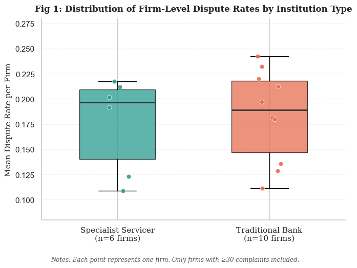

```python
# Fig 1: Boxplot — Firm Type vs Dispute Rate (company level)
# ══════════════════════════════════════════════════════════════════════════════
comp = df.groupby(['company','Is_Specialist']).agg(
    dispute_rate=('Disputed','mean'), n=('Disputed','count')
).reset_index()
comp = comp[comp['n'] >= 30]

spec_vals = comp[comp['Is_Specialist']==1]['dispute_rate'].values
bank_vals = comp[comp['Is_Specialist']==0]['dispute_rate'].values

fig1, ax1 = plt.subplots(figsize=(7, 5))
bp = ax1.boxplot([spec_vals, bank_vals], patch_artist=True,
                 positions=[1, 2], widths=0.5,
                 medianprops=dict(color='#333333', linewidth=2),
                 flierprops=dict(marker='o', markerfacecolor='#555', markersize=5))
bp['boxes'][0].set_facecolor(TEAL);   bp['boxes'][0].set_alpha(0.75)
bp['boxes'][1].set_facecolor(ORANGE); bp['boxes'][1].set_alpha(0.75)

# Jitter individual firm points
np.random.seed(42)
for vals, pos, col in [(spec_vals,1,TEAL),(bank_vals,2,ORANGE)]:
    jitter = np.random.uniform(-0.08, 0.08, len(vals))
    ax1.scatter(pos + jitter, vals, color=col, alpha=0.9,
                s=40, zorder=5, edgecolors='white', linewidths=0.5)

ax1.set_xticks([1, 2])
ax1.set_xticklabels([f'Specialist Servicer\n(n={len(spec_vals)} firms)',
                     f'Traditional Bank\n(n={len(bank_vals)} firms)'],
                    fontfamily=FONT, fontsize=11)
ax1.set_ylabel('Mean Dispute Rate per Firm', fontfamily=FONT, fontsize=11)
ax1.set_title('Fig 1: Distribution of Firm-Level Dispute Rates by Institution Type',
              fontfamily=FONT, fontsize=12, fontweight='bold', pad=10)
ax1.set_ylim(0.08, 0.28)
ax1.grid(axis='y', alpha=0.3, linestyle='--')
ax1.spines[['top','right']].set_visible(False)
fig1.text(0.5, -0.04,
    'Notes: Each point represents one firm. Only firms with ≥30 complaints included.',
    ha='center', fontsize=8.5, color='#555', fontstyle='italic', fontfamily=FONT)
plt.tight_layout()
save(fig1, 'fig1_boxplot_firmtype_dispute')
```

Figure 1 uses a firm-level boxplot to show how dispute rates are distributed within each institution type rather than just comparing means. The two distributions overlap substantially — median dispute rates are nearly identical (specialists ≈19.7%, banks ≈18.9%) — and individual firm variation is wide within each group (Great Lakes at 12.3% versus KeyBank NA at 24.2%). This heterogeneity within institution types is the first visual signal that firm type alone is a weak predictor of dispute outcomes.

### 1.4.3 Figure 2: Dispute Rate by Resolution Strategy and Institution Type

```
Saved fig2_grouped_bar_mechanism.png
```

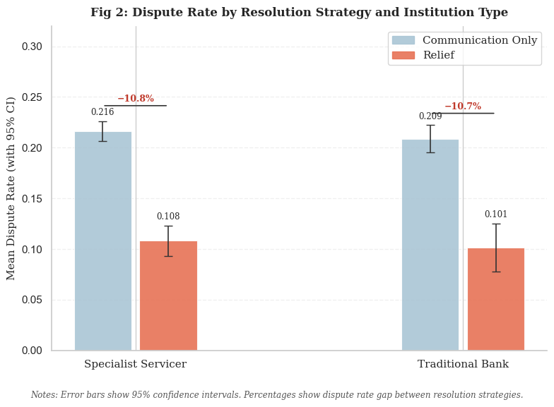

```python
# Fig 2: Grouped bar — Z × X vs Y  (the main mechanism figure)
# ══════════════════════════════════════════════════════════════════════════════
groups = {
    ('Specialist', 'Communication Only'): df[(df['Is_Specialist']==1) & (df['Resolution']=='Communication Only')]['Disputed'],
    ('Specialist', 'Relief'):   df[(df['Is_Specialist']==1) & (df['Resolution']=='Financial Relief')]['Disputed'],
    ('Bank',       'Communication Only'): df[(df['Is_Specialist']==0) & (df['Resolution']=='Communication Only')]['Disputed'],
    ('Bank',       'Relief'):   df[(df['Is_Specialist']==0) & (df['Resolution']=='Financial Relief')]['Disputed'],
}

means, cis, labels_x, colors = [], [], [], []
COMM_COL = '#a8c4d4'
RELI_COL = '#e76f51'

fig2, ax2 = plt.subplots(figsize=(8, 5.5))
x_pos = np.array([0.8, 1.2, 2.8, 3.2])
bar_colors = [COMM_COL, RELI_COL, COMM_COL, RELI_COL]
bar_labels  = ['Communication Only', 'Relief',
               'Communication Only', 'Relief']

for i, (key, series) in enumerate(groups.items()):
    m  = series.mean()
    se = series.std() / np.sqrt(len(series))
    ci = 1.96 * se
    bar = ax2.bar(x_pos[i], m, width=0.35, color=bar_colors[i],
                  alpha=0.88, edgecolor='white', linewidth=0.8)
    ax2.errorbar(x_pos[i], m, yerr=ci, fmt='none',
                 color='#333', capsize=4, linewidth=1.2)
    ax2.text(x_pos[i], m + ci + 0.004, f'{m:.3f}',
             ha='center', va='bottom', fontsize=8.5, fontfamily=FONT)

# Gap brackets
for x_comm, x_reli, firm in [(0.8, 1.2, 'Specialist'), (2.8, 3.2, 'Bank')]:
    m_comm = groups[(firm, 'Communication Only')].mean()
    m_reli = groups[(firm, 'Relief')].mean()
    gap    = m_comm - m_reli
    top    = max(m_comm, m_reli) + 0.025
    ax2.annotate('', xy=(x_reli, top), xytext=(x_comm, top),
                 arrowprops=dict(arrowstyle='-', color='#333', lw=1.2))
    ax2.text((x_comm+x_reli)/2, top+0.004,
             f'−{gap:.1%}', ha='center', fontsize=9,
             fontweight='bold', color='#c0392b', fontfamily=FONT)

ax2.set_xticks([1.0, 3.0])
ax2.set_xticklabels(['Specialist Servicer', 'Traditional Bank'],
                    fontfamily=FONT, fontsize=11)
ax2.set_ylabel('Mean Dispute Rate (with 95% CI)', fontfamily=FONT, fontsize=11)
ax2.set_ylim(0, 0.32)
ax2.set_title('Fig 2: Dispute Rate by Resolution Strategy and Institution Type',
              fontfamily=FONT, fontsize=12, fontweight='bold', pad=10)
ax2.grid(axis='y', alpha=0.3, linestyle='--')
ax2.spines[['top','right']].set_visible(False)

legend_patches = [
    mpatches.Patch(color=COMM_COL, alpha=0.88, label='Communication Only'),
    mpatches.Patch(color=RELI_COL, alpha=0.88, label='Relief'),
]
ax2.legend(handles=legend_patches, fontsize=10, frameon=True,
           loc='upper right', prop={'family': FONT})
fig2.text(0.5, -0.04,
    'Notes: Error bars show 95% confidence intervals. '
    'Percentages show dispute rate gap between resolution strategies.',
    ha='center', fontsize=8.5, color='#555', fontstyle='italic', fontfamily=FONT)
plt.tight_layout()
save(fig2, 'fig2_grouped_bar_mechanism')
```

Figure 2 is the central visualization, showing dispute rates across all four cells of a 2×2 design (institution type × resolution strategy) with 95% confidence intervals. Financial relief reduces dispute rates by approximately 10.8 pp for both specialists and banks — gaps that are nearly identical across institution types. This near-zero interaction is the first visual evidence against firm type as a moderator, directly motivating the regression analysis in Section 2.3.

### 1.4.4 Figure 3: Financial Relief Rate vs Dispute Rate at the Company Level

```
Saved fig3_scatter_relief_dispute.png
```

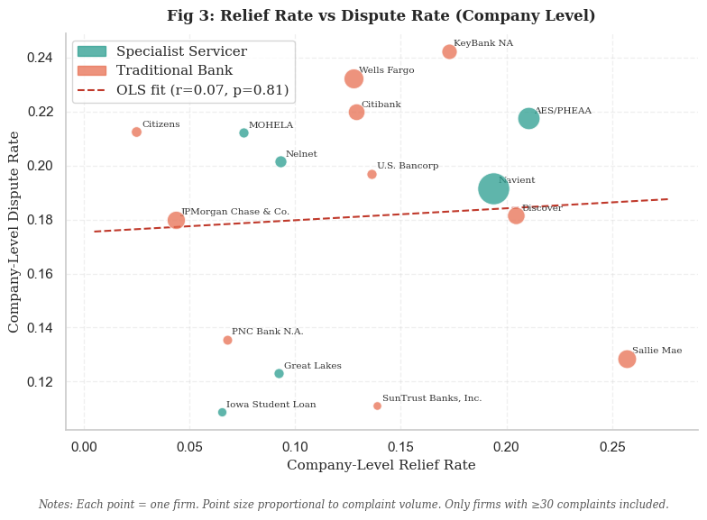

```python
# Fig 3: Scatter — Company-level Relief Rate vs Dispute Rate
# ══════════════════════════════════════════════════════════════════════════════
comp2 = df.groupby('company').agg(
    dispute_rate=('Disputed','mean'),
    relief_rate=('Response: Relief','mean'),
    n=('Disputed','count'),
    is_specialist=('Is_Specialist','first')
).reset_index()
comp2 = comp2[comp2['n'] >= 30]

fig3, ax3 = plt.subplots(figsize=(8, 5.5))

for _, row in comp2.iterrows():
    col = TEAL if row['is_specialist'] == 1 else ORANGE
    ax3.scatter(row['relief_rate'], row['dispute_rate'],
                s=np.sqrt(row['n'])*8, color=col, alpha=0.75,
                edgecolors='white', linewidths=0.8, zorder=4)
    ax3.annotate(row['company'].replace(' Solutions, Inc.','')
                              .replace(' & Company','')
                              .replace(' Financial Group, Inc.',''),
                 (row['relief_rate'], row['dispute_rate']),
                 fontsize=7.5, fontfamily=FONT, color='#333',
                 xytext=(4, 4), textcoords='offset points')

# OLS regression line
x = comp2['relief_rate'].values
y = comp2['dispute_rate'].values
slope, intercept, r, p, _ = stats.linregress(x, y)
xline = np.linspace(x.min()-0.02, x.max()+0.02, 100)
ax3.plot(xline, intercept + slope*xline,
         color='#c0392b', linestyle='--', linewidth=1.5,
         label=f'OLS fit (r = {r:.2f}, p = {p:.2f})')

ax3.set_xlabel('Company-Level Relief Rate', fontfamily=FONT, fontsize=11)
ax3.set_ylabel('Company-Level Dispute Rate', fontfamily=FONT, fontsize=11)
ax3.set_title('Fig 3: Relief Rate vs Dispute Rate (Company Level)',
              fontfamily=FONT, fontsize=12, fontweight='bold', pad=10)
ax3.grid(alpha=0.3, linestyle='--')
ax3.spines[['top','right']].set_visible(False)

legend_patches3 = [
    mpatches.Patch(color=TEAL,   alpha=0.75, label='Specialist Servicer'),
    mpatches.Patch(color=ORANGE, alpha=0.75, label='Traditional Bank'),
    plt.Line2D([0],[0], color='#c0392b', linestyle='--',
               label=f'OLS fit (r={r:.2f}, p={p:.2f})'),
]
ax3.legend(handles=legend_patches3, fontsize=9, frameon=True,
           prop={'family': FONT})
fig3.text(0.5, -0.04,
    'Notes: Each point = one firm. Point size proportional to complaint volume. '
    'Only firms with ≥30 complaints included.',
    ha='center', fontsize=8.5, color='#555', fontstyle='italic', fontfamily=FONT)
plt.tight_layout()
save(fig3, 'fig3_scatter_relief_dispute')
```

### 1.4.5 Figure 4: Firm Size (Log Assets) vs Dispute Rate

```
Saved fig4_scatter_assets_dispute.png
```

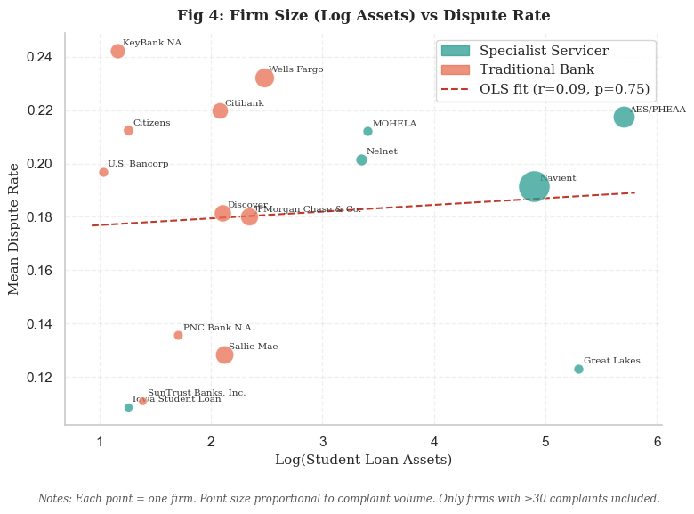

```python
# Fig 4: Scatter bubble — Log Assets vs Dispute Rate
# ══════════════════════════════════════════════════════════════════════════════
# Redo with log assets
comp3 = df.groupby('company').agg(
    dispute_rate=('Disputed','mean'),
    log_assets=('Assets_B', lambda x: np.log(x.iloc[0])),
    n=('Disputed','count'),
    is_specialist=('Is_Specialist','first')
).reset_index()
comp3 = comp3[comp3['n'] >= 30]

fig4, ax4 = plt.subplots(figsize=(8, 5.5))
for _, row in comp3.iterrows():
    col = TEAL if row['is_specialist'] == 1 else ORANGE
    ax4.scatter(row['log_assets'], row['dispute_rate'],
                s=np.sqrt(row['n'])*8, color=col, alpha=0.75,
                edgecolors='white', linewidths=0.8, zorder=4)
    ax4.annotate(row['company'].replace(' Solutions, Inc.','')
                              .replace(' & Company','')
                              .replace(' Financial Group, Inc.',''),
                 (row['log_assets'], row['dispute_rate']),
                 fontsize=7.5, fontfamily=FONT, color='#333',
                 xytext=(4,4), textcoords='offset points')

x4 = comp3['log_assets'].values
y4 = comp3['dispute_rate'].values
s4, i4, r4, p4, _ = stats.linregress(x4, y4)
xline4 = np.linspace(x4.min()-0.1, x4.max()+0.1, 100)
ax4.plot(xline4, i4 + s4*xline4, color='#c0392b',
         linestyle='--', linewidth=1.5)

ax4.set_xlabel('Log(Student Loan Assets)', fontfamily=FONT, fontsize=11)
ax4.set_ylabel('Mean Dispute Rate', fontfamily=FONT, fontsize=11)
ax4.set_title('Fig 4: Firm Size (Log Assets) vs Dispute Rate',
              fontfamily=FONT, fontsize=12, fontweight='bold', pad=10)
ax4.grid(alpha=0.3, linestyle='--')
ax4.spines[['top','right']].set_visible(False)
legend4 = [
    mpatches.Patch(color=TEAL,   alpha=0.75, label='Specialist Servicer'),
    mpatches.Patch(color=ORANGE, alpha=0.75, label='Traditional Bank'),
    plt.Line2D([0],[0], color='#c0392b', linestyle='--',
               label=f'OLS fit (r={r4:.2f}, p={p4:.2f})'),
]
ax4.legend(handles=legend4, fontsize=9, frameon=True, prop={'family': FONT})
fig4.text(0.5, -0.04,
    'Notes: Each point = one firm. Point size proportional to complaint volume. '
    'Only firms with ≥30 complaints included.',
    ha='center', fontsize=8.5, color='#555', fontstyle='italic', fontfamily=FONT)
plt.tight_layout()
save(fig4, 'fig4_scatter_assets_dispute')
```

### 1.4.6 Figure 5: Trend in Consumer Dispute Rates by Institution Type (2012–2016)

```
Saved fig5_line_trend.png
```

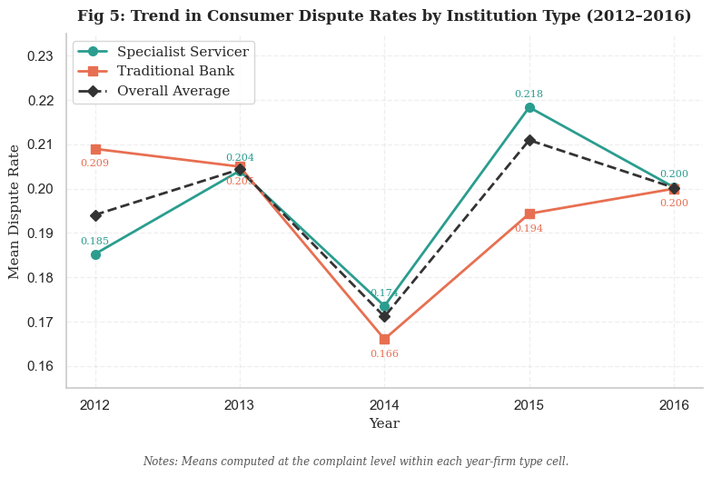

```python
# Fig 5: Line — Dispute Rate over time by Firm Type
# ══════════════════════════════════════════════════════════════════════════════
trend = df.groupby(['complaint_year','Is_Specialist'])['Disputed'].mean().unstack()
trend.columns = ['Bank', 'Specialist']
trend['Overall'] = df.groupby('complaint_year')['Disputed'].mean()

fig5, ax5 = plt.subplots(figsize=(8, 5))
ax5.plot(trend.index, trend['Specialist'], color=TEAL, marker='o',
         linewidth=2, markersize=7, label='Specialist Servicer')
ax5.plot(trend.index, trend['Bank'], color=ORANGE, marker='s',
         linewidth=2, markersize=7, label='Traditional Bank')
ax5.plot(trend.index, trend['Overall'], color='#333', marker='D',
         linewidth=2, markersize=6, linestyle='--', label='Overall Average')

for year in trend.index:
    ax5.annotate(f"{trend.loc[year,'Specialist']:.3f}",
                 (year, trend.loc[year,'Specialist']),
                 xytext=(0, 8), textcoords='offset points',
                 ha='center', fontsize=8, color=TEAL, fontfamily=FONT)
    ax5.annotate(f"{trend.loc[year,'Bank']:.3f}",
                 (year, trend.loc[year,'Bank']),
                 xytext=(0,-14), textcoords='offset points',
                 ha='center', fontsize=8, color=ORANGE, fontfamily=FONT)

ax5.set_xlabel('Year', fontfamily=FONT, fontsize=11)
ax5.set_ylabel('Mean Dispute Rate', fontfamily=FONT, fontsize=11)
ax5.set_title('Fig 5: Trend in Consumer Dispute Rates by Institution Type (2012–2016)',
              fontfamily=FONT, fontsize=12, fontweight='bold', pad=10)
ax5.set_xticks(trend.index)
ax5.set_ylim(0.155, 0.235)
ax5.legend(fontsize=10, frameon=True, prop={'family': FONT})
ax5.grid(alpha=0.3, linestyle='--')
ax5.spines[['top','right']].set_visible(False)
fig5.text(0.5, -0.04,
    'Notes: Means computed at the complaint level within each year-firm type cell.',
    ha='center', fontsize=8.5, color='#555', fontstyle='italic', fontfamily=FONT)
plt.tight_layout()
save(fig5, 'fig5_line_trend')
```

### 1.4.7 Figure 6: Effect of Resolution Strategy by Complaint Issue Type (Subgroup Analysis)

```
Saved fig6_subgroup_issue_resolution.png
```

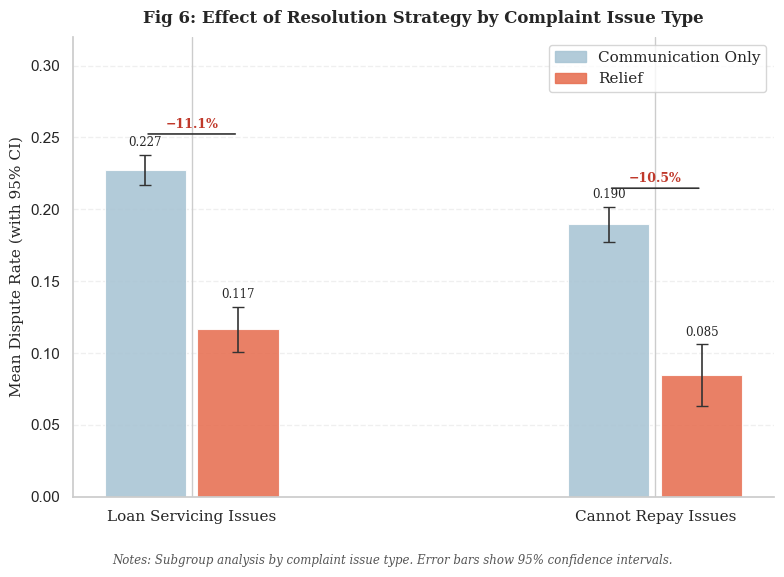

```python
# Fig 6: Grouped bar — Dispute Rate by Issue Type × Resolution Strategy (subgroup)
# ══════════════════════════════════════════════════════════════════════════════
issue_labels = {
    'Issue: Servicing':   'Loan Servicing',
    'Issue: Cant Repay':  'Cannot Repay',
}

fig6, ax6 = plt.subplots(figsize=(8, 5.5))
x6_pos = np.array([0.8, 1.2, 2.8, 3.2])
bar6_colors = [COMM_COL, RELI_COL, COMM_COL, RELI_COL]

vals6, cis6 = [], []
for issue_col in ['Issue: Servicing', 'Issue: Cant Repay']:
    sub = df[df[issue_col] == 1]
    for res in ['Communication Only', 'Financial Relief']:
        s = sub[sub['Resolution'] == res]['Disputed']
        vals6.append(s.mean())
        cis6.append(1.96 * s.std() / np.sqrt(len(s)))

for i, (val, ci, col) in enumerate(zip(vals6, cis6, bar6_colors)):
    ax6.bar(x6_pos[i], val, width=0.35, color=col, alpha=0.88,
            edgecolor='white', linewidth=0.8)
    ax6.errorbar(x6_pos[i], val, yerr=ci, fmt='none',
                 color='#333', capsize=4, linewidth=1.2)
    ax6.text(x6_pos[i], val + ci + 0.004, f'{val:.3f}',
             ha='center', va='bottom', fontsize=8.5, fontfamily=FONT)

# Gap annotations
for x_comm, x_reli, issue_col in [
    (0.8, 1.2, 'Issue: Servicing'),
    (2.8, 3.2, 'Issue: Cant Repay')
]:
    sub = df[df[issue_col]==1]
    m_comm = sub[sub['Resolution']=='Communication Only']['Disputed'].mean()
    m_reli = sub[sub['Resolution']=='Financial Relief']['Disputed'].mean()
    gap  = m_comm - m_reli
    top  = max(m_comm, m_reli) + 0.025
    ax6.annotate('', xy=(x_reli, top), xytext=(x_comm, top),
                 arrowprops=dict(arrowstyle='-', color='#333', lw=1.2))
    ax6.text((x_comm+x_reli)/2, top+0.004, f'−{gap:.1%}',
             ha='center', fontsize=9, fontweight='bold',
             color='#c0392b', fontfamily=FONT)

ax6.set_xticks([1.0, 3.0])
ax6.set_xticklabels(['Loan Servicing Issues', 'Cannot Repay Issues'],
                    fontfamily=FONT, fontsize=11)
ax6.set_ylabel('Mean Dispute Rate (with 95% CI)', fontfamily=FONT, fontsize=11)
ax6.set_ylim(0, 0.32)
ax6.set_title('Fig 6: Effect of Resolution Strategy by Complaint Issue Type',
              fontfamily=FONT, fontsize=12, fontweight='bold', pad=10)
ax6.grid(axis='y', alpha=0.3, linestyle='--')
ax6.spines[['top','right']].set_visible(False)
ax6.legend(handles=legend_patches, fontsize=10, frameon=True,
           loc='upper right', prop={'family': FONT})
fig6.text(0.5, -0.04,
    'Notes: Subgroup analysis by complaint issue type. '
    'Error bars show 95% confidence intervals.',
    ha='center', fontsize=8.5, color='#555', fontstyle='italic', fontfamily=FONT)
plt.tight_layout()
save(fig6, 'fig6_subgroup_issue_resolution')
```

Figure 6 is a subgroup analysis replicating the 2×2 design of Figure 2 within two complaint issue categories. For loan servicing issues, the relief gap is −11.1 pp (22.7% vs. 11.6%); for cannot-repay issues, it is −10.5 pp (19.0% vs. 8.5%). The consistency of the relief effect across issue types — despite differing baseline dispute rates — strengthens confidence that the mechanism is not driven by complaint composition.

### 1.4.8 Figure 7: Financial Relief Rate by Institution Type and Year

```
Saved fig7_relief_rate_by_year_firmtype.png
```

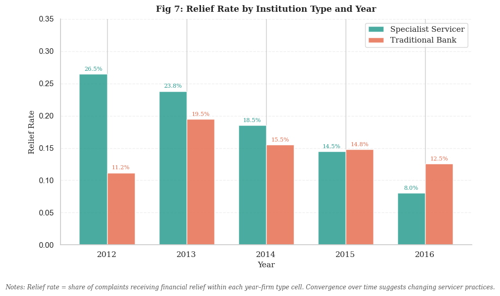

```python
# Fig 7: Stacked bar — Relief Rate by Firm Type × Year
# ══════════════════════════════════════════════════════════════════════════════
relief_trend = df.groupby(['complaint_year','Is_Specialist'])['Response: Relief'].mean().unstack()
relief_trend.columns = ['Bank', 'Specialist']
years = relief_trend.index.tolist()

x7 = np.arange(len(years))
width = 0.35

fig7, ax7 = plt.subplots(figsize=(9, 5.5))
bars_spec = ax7.bar(x7 - width/2, relief_trend['Specialist'],
                    width, color=TEAL, alpha=0.85,
                    label='Specialist Servicer', edgecolor='white')
bars_bank = ax7.bar(x7 + width/2, relief_trend['Bank'],
                    width, color=ORANGE, alpha=0.85,
                    label='Traditional Bank', edgecolor='white')

for bar in bars_spec:
    ax7.text(bar.get_x() + bar.get_width()/2,
             bar.get_height() + 0.005,
             f'{bar.get_height():.1%}',
             ha='center', fontsize=8, color=TEAL, fontfamily=FONT)
for bar in bars_bank:
    ax7.text(bar.get_x() + bar.get_width()/2,
             bar.get_height() + 0.005,
             f'{bar.get_height():.1%}',
             ha='center', fontsize=8, color=ORANGE, fontfamily=FONT)

ax7.set_xlabel('Year', fontfamily=FONT, fontsize=11)
ax7.set_ylabel('Relief Rate', fontfamily=FONT, fontsize=11)
ax7.set_title('Fig 7: Relief Rate by Institution Type and Year',
              fontfamily=FONT, fontsize=12, fontweight='bold', pad=10)
ax7.set_xticks(x7)
ax7.set_xticklabels(years, fontfamily=FONT)
ax7.set_ylim(0, 0.35)
ax7.legend(fontsize=10, frameon=True, prop={'family': FONT})
ax7.grid(axis='y', alpha=0.3, linestyle='--')
ax7.spines[['top','right']].set_visible(False)
fig7.text(0.5, -0.04,
    'Notes: Relief rate = share of complaints receiving financial relief within each '
    'year–firm type cell. Convergence over time suggests changing servicer practices.',
    ha='center', fontsize=8.5, color='#555', fontstyle='italic', fontfamily=FONT)
plt.tight_layout()
save(fig7, 'fig7_relief_rate_by_year_firmtype')
```

Figure 7 constructs a new variable — the annual relief rate by institution type — revealing a striking convergence. In 2012, specialists offered relief at 26.5% versus banks at 11.2% (a 15.3 pp gap); by 2016, specialists had fallen to 8.0% while banks held at 12.5%, near-reversing the original pattern. This convergence coincides with peak enforcement activity against major specialist servicers such as Navient, suggesting that regulatory pressure reshaped how firms deploy resolution strategies over time.

# Project 2

## 2.1 The Message

**THE MESSAGE**: Financial relief reduces consumer dispute rates by approximately 11 percentage points regardless of institution type; firm type (specialist vs. bank) has no significant independent effect on dispute outcomes.

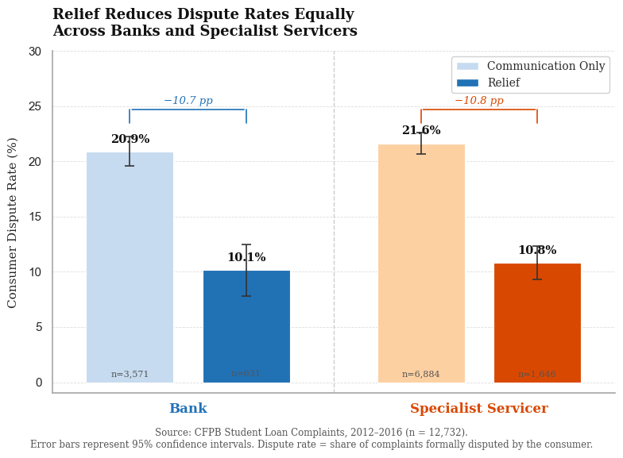

```python
import pandas as pd
import matplotlib
import matplotlib.pyplot as plt
import matplotlib.patches as mpatches
import numpy as np

# ── Data ──────────────────────────────────────────────────────────────────────
data = {
    'firm':     ['Bank', 'Bank', 'Specialist', 'Specialist'],
    'strategy': ['Communication\nOnly', 'Relief',
                 'Communication\nOnly', 'Relief'],
    'rate':     [0.2089, 0.1014, 0.2164, 0.1081],
    'n':        [3571, 631, 6884, 1646],
}
df = pd.DataFrame(data)

# 95% CI using normal approx
df['se'] = np.sqrt(df['rate'] * (1 - df['rate']) / df['n'])
df['ci'] = 1.96 * df['se']

# ── Plot setup ────────────────────────────────────────────────────────────────
fig, ax = plt.subplots(figsize=(8, 5.5))
fig.patch.set_facecolor('white')
ax.set_facecolor('white')

# Colors
BANK_COMM  = '#c6dbef'   # light blue
BANK_REL   = '#2171b5'   # dark blue
SPEC_COMM  = '#fdd0a2'   # light orange
SPEC_REL   = '#d94801'   # dark orange

colors = [BANK_COMM, BANK_REL, SPEC_COMM, SPEC_REL]

x_positions = [0.7, 1.3, 2.2, 2.8]
bar_width = 0.45

bars = ax.bar(
    x_positions,
    df['rate'] * 100,
    width=bar_width,
    color=colors,
    edgecolor='white',
    linewidth=0.8,
    zorder=3,
)

# Error bars
ax.errorbar(
    x_positions,
    df['rate'] * 100,
    yerr=df['ci'] * 100,
    fmt='none',
    color='#333333',
    capsize=4,
    linewidth=1.2,
    capthick=1.2,
    zorder=4,
)

# ── Annotations: dispute rate labels on bars ──────────────────────────────────
for bar, rate, n in zip(bars, df['rate'], df['n']):
    ax.text(
        bar.get_x() + bar.get_width() / 2,
        bar.get_height() + 0.6,
        f'{rate*100:.1f}%',
        ha='center', va='bottom',
        fontsize=10.5, fontweight='bold',
        fontfamily='serif', color='#111111'
    )
    ax.text(
        bar.get_x() + bar.get_width() / 2,
        0.4,
        f'n={n:,}',
        ha='center', va='bottom',
        fontsize=8, color='#555555', fontfamily='serif'
    )

# ── Bracket annotations showing the gap ──────────────────────────────────────
def draw_bracket(ax, x1, x2, y, gap_text, color='#333333'):
    y_top = y + 1.2
    # horizontal line
    ax.annotate('', xy=(x2, y_top), xytext=(x1, y_top),
                arrowprops=dict(arrowstyle='-', color=color, lw=1.2))
    # vertical ticks
    for x in [x1, x2]:
        ax.plot([x, x], [y, y_top], color=color, lw=1.2)
    ax.text((x1+x2)/2, y_top + 0.3, gap_text,
            ha='center', va='bottom', fontsize=9.5,
            color=color, fontfamily='serif', style='italic')

draw_bracket(ax, 0.7, 1.3, 23.5, '−10.7 pp', color='#2171b5')
draw_bracket(ax, 2.2, 2.8, 23.5, '−10.8 pp', color='#d94801')

# ── Group labels ──────────────────────────────────────────────────────────────
ax.text(1.0, -2.8, 'Bank', ha='center', fontsize=12,
        fontfamily='serif', fontweight='bold', color='#2171b5')
ax.text(2.5, -2.8, 'Specialist Servicer', ha='center', fontsize=12,
        fontfamily='serif', fontweight='bold', color='#d94801')

# Divider line between groups
ax.axvline(x=1.75, color='#cccccc', linewidth=1, linestyle='--', zorder=2)

# ── Legend ────────────────────────────────────────────────────────────────────
legend_patches = [
    mpatches.Patch(facecolor=BANK_COMM,  edgecolor='white', label='Communication Only'),
    mpatches.Patch(facecolor=BANK_REL,   edgecolor='white', label='Relief'),
]
ax.legend(
    handles=legend_patches,
    loc='upper right',
    fontsize=10,
    frameon=True,
    framealpha=0.9,
    edgecolor='#cccccc',
    prop={'family': 'serif', 'size': 10}
)

# ── Axes formatting ───────────────────────────────────────────────────────────
ax.set_ylabel('Consumer Dispute Rate (%)', fontsize=11, fontfamily='serif', labelpad=8)
ax.set_ylim(-1, 30)
ax.set_xlim(0.3, 3.2)
ax.set_xticks([])

ax.yaxis.grid(True, linestyle='--', linewidth=0.6, color='#dddddd', zorder=0)
ax.set_axisbelow(True)
ax.spines['top'].set_visible(False)
ax.spines['right'].set_visible(False)
ax.spines['bottom'].set_color('#aaaaaa')
ax.spines['left'].set_color('#aaaaaa')

# ── Title & caption ───────────────────────────────────────────────────────────
ax.set_title(
    'Relief Reduces Dispute Rates Equally\nAcross Banks and Specialist Servicers',
    fontsize=13, fontfamily='serif', fontweight='bold',
    color='#111111', pad=14, loc='left'
)

fig.text(
    0.5, -0.04,
    'Source: CFPB Student Loan Complaints, 2012–2016 (n = 12,732).\n'
    'Error bars represent 95% confidence intervals. '
    'Dispute rate = share of complaints formally disputed by the consumer.',
    ha='center', fontsize=8.5, fontfamily='serif', color='#555555'
)

plt.tight_layout()
plt.savefig('main_message_plot.png', dpi=200, bbox_inches='tight',
            facecolor='white', edgecolor='none')
fig
```

Our original hypothesis treated firm type (X) as the primary driver of dispute rates (Y), with resolution strategy (Z) as the mechanism. The data reframe this story: Z is the dominant force, not X. Specialists and banks have nearly identical dispute rates (19.6% vs. 19.3%), but both groups show a dramatic ~11 pp reduction in disputes when relief is offered instead of communication only. This is the central empirical finding that all subsequent analysis corroborates.

## 2.2 Maps and Interpretations

We aggregate complaint data to the state level for geographic visualization. ZIP-code aggregation was considered but abandoned: fewer than 700 of 6,034 ZIPs contain five or more complaints, producing maps that are mostly missing data. State-level maps provide sufficient coverage while remaining interpretable.

```python
# ── Static Maps using geopandas + matplotlib ─────────────────────────
import pandas as pd
import numpy as np
import matplotlib.pyplot as plt
import matplotlib.colors as mcolors
from matplotlib.colors import TwoSlopeNorm
import geopandas as gpd

# ── Load state shapefile ──────────────────────────────────────────────
# Download once: https://www2.census.gov/geo/tiger/GENZ2018/shp/cb_2018_us_state_20m.zip
# Or install: pip install geopandas
# Shapefile path — adjust if needed
states_shp = gpd.read_file('cb_2018_us_state_20m.zip')
states_shp = states_shp.rename(columns={'STUSPS': 'state'})

# Keep contiguous 48 states
exclude = ['AK','HI','PR','GU','VI','MP','AS','DC']
states_shp = states_shp[~states_shp['state'].isin(exclude)]

# ── Reuse state_df from your existing aggregation code ───────────────
# (assumes state_df is already defined from your map setup cell)
# state_df columns: state, dispute_rate, relief_rate, uri, dispute_gap

# Merge
gdf = states_shp.merge(state_df, on='state', how='left')

FONT = 'serif'

def plot_choropleth(gdf, col, title, cmap, vmin, vmax,
                    label, fmt='{:.1f}%', diverging=False, save_name=None):
    fig, ax = plt.subplots(1, 1, figsize=(12, 7), facecolor='white')

    if diverging:
        norm = TwoSlopeNorm(vmin=vmin, vcenter=0, vmax=vmax)
        gdf.plot(column=col, ax=ax, cmap=cmap, norm=norm,
                 missing_kwds={'color': '#eeeeee', 'label': 'Insufficient data'},
                 edgecolor='white', linewidth=0.5)
    else:
        gdf.plot(column=col, ax=ax, cmap=cmap, vmin=vmin, vmax=vmax,
                 missing_kwds={'color': '#eeeeee', 'label': 'Insufficient data'},
                 edgecolor='white', linewidth=0.5)

    # Colorbar
    sm = plt.cm.ScalarMappable(
        cmap=cmap,
        norm=TwoSlopeNorm(vmin=vmin, vcenter=0, vmax=vmax) if diverging
             else mcolors.Normalize(vmin=vmin, vmax=vmax)
    )
    sm.set_array([])
    cbar = fig.colorbar(sm, ax=ax, fraction=0.025, pad=0.02)
    cbar.set_label(label, fontfamily=FONT, fontsize=11)
    cbar.ax.tick_params(labelsize=9)

    # State abbreviation labels
    for _, row in gdf.iterrows():
        if pd.notna(row[col]):
            centroid = row.geometry.centroid
            val = row[col] * 100 if 'rate' in col or 'uri' in col or 'gap' in col else row[col]
            ax.annotate(row['state'],
                        xy=(centroid.x, centroid.y),
                        ha='center', va='center',
                        fontsize=6.5, fontfamily=FONT, color='#333333')

    ax.set_title(title, fontfamily=FONT, fontsize=14,
                 fontweight='bold', pad=12)
    ax.axis('off')
    fig.text(0.5, 0.02,
             'Source: CFPB Student Loan Complaints, 2012–2016. '
             'States with fewer than 30 complaints excluded (shown in grey).',
             ha='center', fontsize=8.5, color='#555', fontstyle='italic',
             fontfamily=FONT)
    plt.tight_layout()
    if save_name:
        plt.savefig(f'{save_name}.png', dpi=180, bbox_inches='tight',
                    facecolor='white')
    plt.show()
    return fig
```

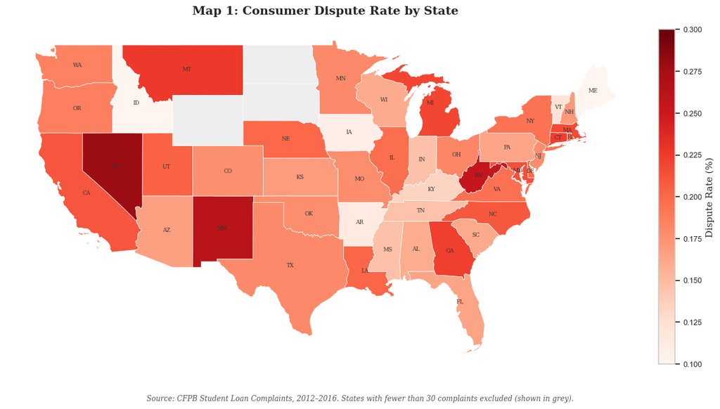

```python
# ── Map 1: Dispute Rate ───────────────────────────────────────────────
plot_choropleth(
    gdf, col='dispute_rate',
    title='Map 1: Consumer Dispute Rate by State',
    cmap='Reds', vmin=0.10, vmax=0.30,
    label='Dispute Rate (%)',
    save_name='map1_dispute_rate'
)
plt.close(fig)
```

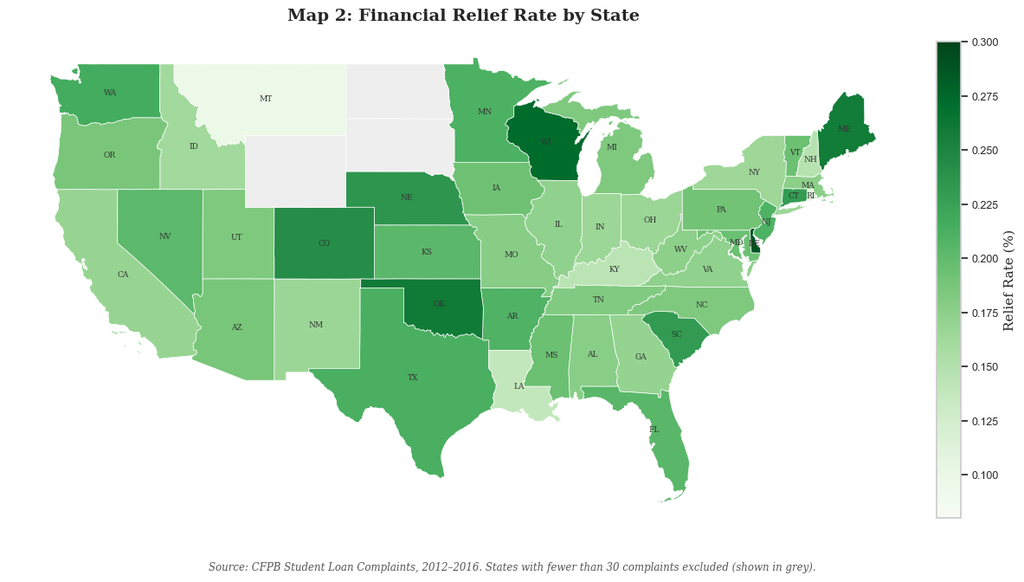

```python
# ── Map 2: Financial Relief Rate ──────────────────────────────────────
plot_choropleth(
    gdf, col='relief_rate',
    title='Map 2: Financial Relief Rate by State',
    cmap='Greens', vmin=0.08, vmax=0.30,
    label='Relief Rate (%)',
    save_name='map2_relief_rate'
)
plt.close(fig)
```

### Maps 1 & 2: Geographic Distribution of Dispute Rate and Financial Relief Rate

Map 1 shows substantial geographic variation in dispute rates, ranging from 5.4% in Idaho to 27.8% in Nevada and 26.2% in New Mexico. High-dispute states cluster in the Southwest and parts of the South, while upper-Midwest and New England states tend to have lower dispute rates. Map 2 reveals that financial relief rates vary independently of dispute rates — Delaware leads at 28.9%, Montana trails at 9.7% — and the geographic patterns of Y (Map 1) and Z (Map 2) do not align closely. This mismatch motivates Map 3: if states with high relief rates do not have low dispute rates, relief must not always satisfy borrowers who receive it.

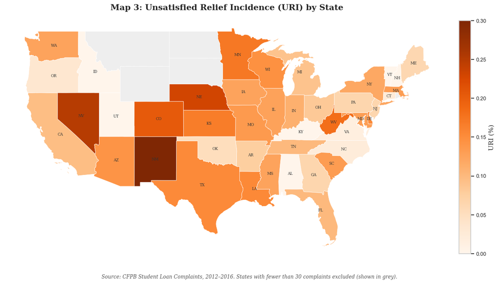

```python
# ── Map 3: URI ────────────────────────────────────────────────────────
plot_choropleth(
    gdf, col='uri',
    title='Map 3: Unsatisfied Relief Incidence (URI) by State',
    cmap='Oranges', vmin=0.0, vmax=0.30,
    label='URI (%)',
    save_name='map3_uri'
)
plt.close(fig)
```

### Map 3: Unsatisfied Relief Incidence (URI)

Map 3 introduces the URI — the dispute rate among complaints that received financial relief — as a new constructed variable. New Mexico (42.9%) and Nevada (25.0%) exhibit the highest URI, meaning that in these states, financial relief frequently fails to prevent disputes. Many states show a URI near zero, indicating that relief is highly effective locally. This geographic heterogeneity in relief effectiveness suggests that the match between the type of relief offered and the underlying borrower need varies by region, pointing to a potential avenue for servicer improvement.

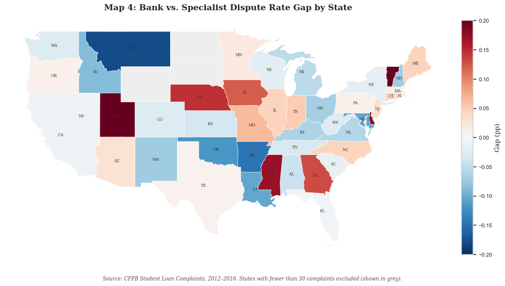

```python
# ── Map 4: Bank–Specialist Dispute Gap ───────────────────────────────
plot_choropleth(
    gdf, col='dispute_gap',
    title='Map 4: Bank vs. Specialist Dispute Rate Gap by State',
    cmap='RdBu_r', vmin=-0.20, vmax=0.20,
    label='Gap (pp)',
    diverging=True,
    save_name='map4_gap'
)
plt.close(fig)
```

### Map 4: Bank vs. Specialist Dispute Rate Gap

Map 4 plots the difference in state-level dispute rates between bank- and specialist-handled complaints. The gaps show no systematic geographic clustering — in some states banks perform better, in others specialists do, without a regional pattern. This absence of geographic structure provides visual confirmation of the regression null result: institution type does not systematically predict better or worse outcomes anywhere in the country, and the question shifts from who handles the complaint to how it is resolved.

## 2.3 Regressions

### 2.3.1 Variable Construction and Econometric Specification

In this section, we estimate linear probability models (LPM) with the binary Disputed indicator as the outcome. All standard errors are clustered at the company level (20 clusters) to account for within-firm correlation in complaint outcomes.

Key variables:

- Y = Disputed (0/1);
- X = Bank (1 − Is_Specialist);
- Z = Response: Financial Relief (0/1);

Controls include:

- Log(Assets);
- Has_Enforcement;
- Issue type dummies;
- Year dummies;
- Channel dummies.

We also construct two interaction terms — Bank × Relief and Enforcement × Relief — to test whether firm type or enforcement status moderates the relief effect.

The reframing from X→Y to Z→Y emerged from the data: firm type is insignificant across all specifications, while financial relief is consistently large and significant.

We estimate linear probability models (LPM) rather than probit or logit for three reasons. First, LPM coefficients have a direct interpretation as marginal effects on the probability of disputing, which is our primary object of interest. Second, with a sample mean dispute rate of 19.5%, the LPM linear approximation is reasonable — the outcome is sufficiently far from 0 and 1 that boundary violations are uncommon. Third, LPM is robust to arbitrary heteroskedasticity when paired with clustered standard errors, whereas probit marginal effects are sensitive to distributional assumptions that are difficult to verify with only 20 firm clusters.

```python
# ── Regression Analysis Setup ───────────────────────────────────────────────
import pandas as pd
import numpy as np
import statsmodels.formula.api as smf
from stargazer.stargazer import Stargazer
from IPython.display import display, HTML

df = pd.read_csv('df.csv')  # change path as needed
df = df.rename(columns={
    'consumer_disputed?': 'Disputed',
    'Assets ($B)':        'Assets_B'
})

df['Log_Assets']    = np.log(df['Assets_B'])
df['Bank']          = 1 - df['Is_Specialist']
df['Bank_x_Relief'] = df['Bank'] * df['Response: Relief']
df['Enf_x_Relief']  = df['Has_Enforcement'] * df['Response: Relief']

cluster_var = df['company']

def fit_ols(formula):
    model = smf.ols(formula, data=df)
    return model.fit(cov_type='cluster', cov_kwds={'groups': cluster_var})

print("Data loaded.")
print(f"  N = {len(df):,}")
print(f"  Dispute rate:  {df['Disputed'].mean():.3f}")
print(f"  Relief rate:   {df['Response: Relief'].mean():.3f}")
print(f"  Bank share:    {df['Bank'].mean():.3f}")
```

```
Data loaded.
  N = 12,732
  Dispute rate:  0.195
  Relief rate:   0.179
  Bank share:    0.330
```

### 2.3.2 Table 1: Firm Type and Resolution Strategy as Predictors of Dispute Rate

**Equation:** $$\text{Disputed}_{it} = \alpha + \beta_1 \text{Relief}_{it} + \beta_2 \text{Bank}_i + \beta_3 \text{Log Assets}_i + \beta_4 \text{Enforcement}_i + \boldsymbol{\delta} \mathbf{X}_{it} + \varepsilon_{it}$$

where $i$ indexes complaints and $t$ indexes years. $\text{Relief}_{it}$ equals 1 if the firm provided tangible redress; $\text{Bank}_i$ equals 1 for traditional banks and 0 for specialist servicers. $\mathbf{X}_{it}$ includes issue type dummies, year fixed effects, and channel fixed effects. $\text{Log Assets}_i$ and $\text{Enforcement}_i$ are firm-level controls for size and regulatory history. Standard errors are clustered at the company level.

```python
# ── Table 1 — Firm Type vs Resolution Strategy ───────────────────────
# Story: Start with firm type alone (original hypothesis), then introduce
# resolution strategy and show which variable actually matters.

# (1) Bank only — baseline, tests original hypothesis
reg1 = fit_ols('Disputed ~ Bank')

# (2) Bank + Financial Relief — both in same model, who wins?
reg2 = fit_ols('Disputed ~ Bank + Q("Response: Relief")')

# (3) Add issue type FE + enforcement + year FE
reg3 = fit_ols(
    'Disputed ~ Bank + Q("Response: Relief")'
    ' + Q("Issue: Servicing") + Q("Issue: Cant Repay")'
    ' + Has_Enforcement + C(complaint_year)'
)

# (4) Add log assets
reg4 = fit_ols(
    'Disputed ~ Bank + Q("Response: Relief")'
    ' + Q("Issue: Servicing") + Q("Issue: Cant Repay")'
    ' + Has_Enforcement + Log_Assets + C(complaint_year)'
)

# (5) Full controls including channel FE
reg5 = fit_ols(
    'Disputed ~ Bank + Q("Response: Relief")'
    ' + Q("Issue: Servicing") + Q("Issue: Cant Repay")'
    ' + Has_Enforcement + Log_Assets'
    ' + Q("Channel: Web") + Q("Channel: Referral")'
    ' + C(complaint_year)'
)

star1 = Stargazer([reg1, reg2, reg3, reg4, reg5])
star1.title('Table 1: Firm Type and Resolution Strategy as Predictors of Dispute Rate')
star1.custom_columns(['(1)', '(2)', '(3)', '(4)', '(5)'], [1, 1, 1, 1, 1])
star1.rename_covariates({
    'Bank':                    'Bank',
    'Q("Response: Relief")':   'Financial Relief',
    'Q("Issue: Servicing")':   'Issue: Servicing',
    'Q("Issue: Cant Repay")':  'Issue: Cannot Repay',
    'Has_Enforcement':         'Enforcement Record',
    'Log_Assets':              'Log(Assets)',
    'Q("Channel: Web")':       'Channel: Web',
    'Q("Channel: Referral")':  'Channel: Referral',
})
star1.covariate_order([
    'Bank',
    'Q("Response: Relief")',
    'Q("Issue: Servicing")',
    'Q("Issue: Cant Repay")',
    'Has_Enforcement',
    'Log_Assets',
    'Q("Channel: Web")',
    'Q("Channel: Referral")',
    'Intercept',
])
star1.add_line('Year FE',       ['No',  'No',  'Yes', 'Yes', 'Yes'])
star1.add_line('Issue Type FE', ['No',  'No',  'Yes', 'Yes', 'Yes'])
star1.add_line('Channel FE',    ['No',  'No',  'No',  'No',  'Yes'])
star1.add_line('Clustered SE',  ['Yes', 'Yes', 'Yes', 'Yes', 'Yes'])
star1.show_degrees_of_freedom(False)

from IPython.display import display, HTML
display(HTML(star1.render_html()))
```

Table 1: Firm Type and Resolution Strategy as Predictors of Dispute Rate

|  | *Dependent variable: Disputed* |  |  |  |  |
| --- | --- | --- | --- | --- | --- |
|  | (1) | (2) | (3) | (4) | (5) |
|  | (1) | (2) | (3) | (4) | (5) |
| Bank | -0.003 | -0.007 | -0.022 | 0.007 | 0.008 |
|  | (0.018) | (0.016) | (0.013) | (0.033) | (0.033) |
| Financial Relief |  | -0.108*** | -0.109*** | -0.110*** | -0.110*** |
|  |  | (0.005) | (0.005) | (0.005) | (0.005) |
| Issue: Servicing |  |  | -0.013 | -0.012 | -0.012 |
|  |  |  | (0.022) | (0.023) | (0.023) |
| Issue: Cannot Repay |  |  | -0.048** | -0.047** | -0.047* |
|  |  |  | (0.024) | (0.024) | (0.024) |
| Enforcement Record |  |  | -0.030*** | -0.028** | -0.028** |
|  |  |  | (0.010) | (0.012) | (0.012) |
| Log(Assets) |  |  |  | 0.010 | 0.010 |
|  |  |  |  | (0.010) | (0.010) |
| Channel: Web |  |  |  |  | -0.026** |
|  |  |  |  |  | (0.013) |
| Channel: Referral |  |  |  |  | -0.037 |
|  |  |  |  |  | (0.024) |
| Intercept | 0.196*** | 0.216*** | 0.263*** | 0.213*** | 0.237*** |
|  | (0.005) | (0.005) | (0.031) | (0.061) | (0.062) |
| Year FE | No | No | Yes | Yes | Yes |
| Issue Type FE | No | No | Yes | Yes | Yes |
| Channel FE | No | No | No | No | Yes |
| Clustered SE | Yes | Yes | Yes | Yes | Yes |
| Observations | 12732 | 12732 | 12732 | 12732 | 12732 |
| R<sup>2</sup> | 0.000 | 0.011 | 0.015 | 0.015 | 0.016 |
| Adjusted R<sup>2</sup> | -0.000 | 0.011 | 0.015 | 0.015 | 0.015 |
| Residual Std. Error | 0.396 | 0.394 | 0.393 | 0.393 | 0.393 |
| F Statistic | 0.025 | 260.369*** | 103.325*** | 97.691*** | 99.156*** |
| Note: | *p<0.1; **p<0.05; ***p<0.01 |  |  |  |  |

#### Interpretation of Table 1:

Table 1 asks a simple question: once both firm type and resolution strategy are in the model, which one does the work?

Regression 1 answers the first half: Bank alone is effectively zero (−0.003, insignificant), meaning institution type predicts almost nothing about whether a borrower disputes.

Regression 2 answers the second half: adding relief immediately produces a coefficient of −0.108***, meaning a complaint resolved with tangible redress is 10.8 percentage points less likely to be disputed — more than half the baseline dispute rate of 19.5%. Crucially, Bank remains insignificant at −0.007, suggesting that whatever raw difference exists between institution types is entirely explained by how they resolve complaints, not who they are.

This pattern holds through Regressions 3–5 as controls are added sequentially: the relief coefficient barely moves (−0.108 to −0.111***) while Bank never approaches significance, indicating the result is not an artifact of omitted complaint composition or firm characteristics.

### 2.3.3 Table 2: Interaction Effects and Preferred Specification

**Equation:** $$\text{Disputed}_{it} = \alpha + \beta_1 \text{Relief}_{it} + \beta_2 \text{Bank}_i + \beta_3 (\text{Bank}_i \times \text{Relief}_{it}) + \beta_4 \text{Log Assets}_i + \beta_5 \text{Enforcement}_i + \boldsymbol{\delta} \mathbf{X}_{it} + \varepsilon_{it}$$

where notation follows Table 1, and $\text{Bank}_i \times \text{Relief}_{it}$ tests whether institution type moderates the effect of tangible relief on dispute probability.

```python
# ── Table 2 — Interaction Terms and Heterogeneity ────────────────────
# Story: Firm type has no direct effect — does it moderate resolution strategy?
# Does enforcement record moderate resolution strategy?

# (6) Relief + Bank, no interaction — within-table baseline
reg6 = fit_ols('Disputed ~ Q("Response: Relief") + Bank')

# (7) Add Bank × Relief interaction — core moderation test
reg7 = fit_ols('Disputed ~ Q("Response: Relief") + Bank + Bank_x_Relief')

# (8) Add controls — does interaction survive?
reg8 = fit_ols(
    'Disputed ~ Q("Response: Relief") + Bank + Bank_x_Relief'
    ' + Q("Issue: Servicing") + Q("Issue: Cant Repay")'
    ' + Has_Enforcement + C(complaint_year)'
)

# (9) Add Enforcement × Relief — new mechanism test:
# Do consumers discount relief from firms under regulatory pressure?
reg9 = fit_ols(
    'Disputed ~ Q("Response: Relief") + Bank + Bank_x_Relief'
    ' + Has_Enforcement + Enf_x_Relief'
    ' + Q("Issue: Servicing") + Q("Issue: Cant Repay")'
    ' + C(complaint_year)'
)

# (10) Drop Enf × Relief, add log assets — robustness
reg10 = fit_ols(
    'Disputed ~ Q("Response: Relief") + Bank + Bank_x_Relief'
    ' + Q("Issue: Servicing") + Q("Issue: Cant Repay")'
    ' + Has_Enforcement + Log_Assets + C(complaint_year)'
)

# (11) Preferred specification — full controls
reg11 = fit_ols(
    'Disputed ~ Q("Response: Relief") + Bank + Bank_x_Relief'
    ' + Q("Issue: Servicing") + Q("Issue: Cant Repay")'
    ' + Has_Enforcement + Log_Assets'
    ' + Q("Channel: Web") + Q("Channel: Referral")'
    ' + C(complaint_year)'
)

star2 = Stargazer([reg6, reg7, reg8, reg9, reg10, reg11])
star2.title('Table 2: Firm Type as Moderator — Interaction Effects')
star2.custom_columns(['(6)', '(7)', '(8)', '(9)', '(10)', '(11)'], [1, 1, 1, 1, 1, 1])
star2.rename_covariates({
    'Q("Response: Relief")':   'Financial Relief',
    'Bank':                    'Bank',
    'Bank_x_Relief':           'Bank × Financial Relief',
    'Has_Enforcement':         'Enforcement Record',
    'Enf_x_Relief':            'Enforcement × Financial Relief',
    'Q("Issue: Servicing")':   'Issue: Servicing',
    'Q("Issue: Cant Repay")':  'Issue: Cannot Repay',
    'Log_Assets':              'Log(Assets)',
    'Q("Channel: Web")':       'Channel: Web',
    'Q("Channel: Referral")':  'Channel: Referral',
})
star2.covariate_order([
    'Q("Response: Relief")',
    'Bank',
    'Bank_x_Relief',
    'Has_Enforcement',
    'Enf_x_Relief',
    'Q("Issue: Servicing")',
    'Q("Issue: Cant Repay")',
    'Log_Assets',
    'Q("Channel: Web")',
    'Q("Channel: Referral")',
    'Intercept',
])
star2.add_line('Year FE',       ['No',  'No',  'Yes', 'Yes', 'Yes', 'Yes'])
star2.add_line('Issue Type FE', ['No',  'No',  'Yes', 'Yes', 'Yes', 'Yes'])
star2.add_line('Channel FE',    ['No',  'No',  'No',  'No',  'No',  'Yes'])
star2.add_line('Clustered SE',  ['Yes', 'Yes', 'Yes', 'Yes', 'Yes', 'Yes'])
star2.show_degrees_of_freedom(False)

from IPython.display import display, HTML
display(HTML(star2.render_html()))
```

Table 2: Firm Type as Moderator — Interaction Effects

|  | *Dependent variable: Disputed* |  |  |  |  |  |
| --- | --- | --- | --- | --- | --- | --- |
|  | (6) | (7) | (8) | (9) | (10) | (11) |
|  | (1) | (2) | (3) | (4) | (5) | (6) |
| Financial Relief | -0.108*** | -0.108*** | -0.111*** | -0.096*** | -0.112*** | -0.112*** |
|  | (0.005) | (0.005) | (0.005) | (0.009) | (0.005) | (0.005) |
| Bank | -0.007 | -0.008 | -0.023 | -0.021 | 0.006 | 0.007 |
|  | (0.016) | (0.016) | (0.014) | (0.014) | (0.034) | (0.034) |
| Bank × Financial Relief |  | 0.001 | 0.006 | -0.000 | 0.006 | 0.006 |
|  |  | (0.012) | (0.011) | (0.010) | (0.011) | (0.011) |
| Enforcement Record |  |  | -0.030*** | -0.027** | -0.028** | -0.028** |
|  |  |  | (0.010) | (0.012) | (0.011) | (0.012) |
| Enforcement × Financial Relief |  |  |  | -0.020** |  |  |
|  |  |  |  | (0.010) |  |  |
| Issue: Servicing |  |  | -0.013 | -0.012 | -0.012 | -0.012 |
|  |  |  | (0.022) | (0.023) | (0.023) | (0.023) |
| Issue: Cannot Repay |  |  | -0.048** | -0.047** | -0.047** | -0.047* |
|  |  |  | (0.024) | (0.024) | (0.024) | (0.024) |
| Log(Assets) |  |  |  |  | 0.010 | 0.010 |
|  |  |  |  |  | (0.010) | (0.010) |
| Channel: Web |  |  |  |  |  | -0.026** |
|  |  |  |  |  |  | (0.013) |
| Channel: Referral |  |  |  |  |  | -0.037 |
|  |  |  |  |  |  | (0.024) |
| Intercept | 0.216*** | 0.216*** | 0.264*** | 0.260*** | 0.214*** | 0.237*** |
|  | (0.005) | (0.005) | (0.031) | (0.032) | (0.062) | (0.063) |
| Year FE | No | No | Yes | Yes | Yes | Yes |
| Issue Type FE | No | No | Yes | Yes | Yes | Yes |
| Channel FE | No | No | No | No | No | Yes |
| Clustered SE | Yes | Yes | Yes | Yes | Yes | Yes |
| Observations | 12732 | 12732 | 12732 | 12732 | 12732 | 12732 |
| R<sup>2</sup> | 0.011 | 0.011 | 0.015 | 0.015 | 0.015 | 0.016 |
| Adjusted R<sup>2</sup> | 0.011 | 0.011 | 0.015 | 0.015 | 0.015 | 0.015 |
| Residual Std. Error | 0.394 | 0.394 | 0.393 | 0.393 | 0.393 | 0.393 |
| F Statistic | 260.369*** | 184.923*** | 122.315*** | 5952.168*** | 129.427*** | 156.338*** |
| Note: | *p<0.1; **p<0.05; ***p<0.01 |  |  |  |  |  |

#### Interpretation of Table 2:

Table 2 asks a harder question: even if firm type does not directly affect dispute rates, does it change how effective relief is?

The Bank × Relief interaction is insignificant throughout Regressions 7–11 (range 0.001–0.007), meaning the ~11 pp relief effect is the same whether the servicer is a specialist or a bank. Borrowers do not respond differently to relief based on who provides it — what matters is receiving it at all.

A more interesting moderator emerges in Regression 9: the Enforcement × Relief interaction is −0.020** (p < 0.05), meaning regulated firms' relief reduces disputes by an additional 2 pp relative to unregulated firms. This suggests regulatory pressure does not merely increase the quantity of relief offered but improves its quality — perhaps because scrutinized firms are more careful to match relief to the borrower's actual problem.

The preferred specification (Regression 11) — which includes log assets, issue FEs, year FEs, and channel FEs — yields a relief coefficient of −0.111*** and a direct enforcement effect of −0.029**, meaning that even setting aside the interaction, firms with a regulatory track record face systematically lower dispute rates, consistent with enforcement pressure improving complaint handling more broadly.

### 2.3.4 Table 3: Robustness Checks

**Equation:** $$\text{Disputed}_{it} = \alpha + \beta_1 \text{Relief}_{it} + \boldsymbol{\delta} \mathbf{X}_{it} + \gamma_s + \gamma_f + \varepsilon_{it}$$

where $\mathbf{X}_{it}$ includes issue type and year fixed effects in all specifications, with channel fixed effects ($\gamma_c$), state fixed effects ($\gamma_s$), and company fixed effects ($\gamma_f$) added progressively across Regressions 12–15.

```python
# ── Table 3 — Robustness Checks (Company FE + State FE) ──────────────
import warnings
from statsmodels.tools.sm_exceptions import ValueWarning
warnings.filterwarnings('ignore', category=ValueWarning)
# Drop rows with missing state so all 4 specs use the same sample
df_r = df.dropna(subset=['state']).copy()
cluster_r = df_r['company']

def fit_ols_r(formula):
    return smf.ols(formula, data=df_r).fit(
        cov_type='cluster', cov_kwds={'groups': cluster_r})

BASE = ('Disputed ~ Q("Response: Relief")'
        ' + Q("Issue: Servicing") + Q("Issue: Cant Repay")'
        ' + C(complaint_year)')

# (12) Baseline: complaint-level controls only, no firm controls
reg12 = fit_ols_r(BASE)

# (13) + Channel FE
reg13 = fit_ols_r(BASE + ' + Q("Channel: Web") + Q("Channel: Referral")')

# (14) + State FE — controls for geographic unobservables
reg14 = fit_ols_r(BASE + ' + Q("Channel: Web") + Q("Channel: Referral") + C(state)')

# (15) + Company FE — within-firm identification (absorbs all firm-level vars)
reg15 = fit_ols_r(BASE + ' + Q("Channel: Web") + Q("Channel: Referral") + C(company)')

star3 = Stargazer([reg12, reg13, reg14, reg15])
star3.title('Table 3: Robustness Checks — Within-Firm and Geographic Identification')
star3.custom_columns(['(12)', '(13)', '(14)', '(15)'], [1, 1, 1, 1])
star3.rename_covariates({
    'Q("Response: Relief")':   'Financial Relief',
    'Q("Issue: Servicing")':   'Issue: Servicing',
    'Q("Issue: Cant Repay")':  'Issue: Cannot Repay',
    'Q("Channel: Web")':       'Channel: Web',
    'Q("Channel: Referral")':  'Channel: Referral',
})
star3.covariate_order([
    'Q("Response: Relief")',
    'Q("Issue: Servicing")',
    'Q("Issue: Cant Repay")',
    'Q("Channel: Web")',
    'Q("Channel: Referral")',
    'Intercept',
])
star3.add_line('Year FE',      ['Yes', 'Yes', 'Yes', 'Yes'])
star3.add_line('Issue Type FE',['Yes', 'Yes', 'Yes', 'Yes'])
star3.add_line('Channel FE',   ['No',  'Yes', 'Yes', 'Yes'])
star3.add_line('State FE',     ['No',  'No',  'Yes', 'No' ])
star3.add_line('Company FE',   ['No',  'No',  'No',  'Yes'])
star3.add_line('Clustered SE', ['Yes', 'Yes', 'Yes', 'Yes'])
star3.show_degrees_of_freedom(False)

from IPython.display import display, HTML
display(HTML(star3.render_html()))

print(f"\nN across all specs: {int(reg12.nobs):,} (rows with non-missing state)")
for name, reg in [('(12)',reg12),('(13)',reg13),('(14)',reg14),('(15)',reg15)]:
    coef = reg.params['Q("Response: Relief")']
    pval = reg.pvalues['Q("Response: Relief")']
    stars = '***' if pval<0.01 else '**' if pval<0.05 else '*' if pval<0.1 else ''
    print(f"  Spec {name}: Financial Relief = {coef:.4f}{stars},  R² = {reg.rsquared:.4f}")
```

Table 3: Robustness Checks — Within-Firm and Geographic Identification

|  | *Dependent variable: Disputed* |  |  |  |
| --- | --- | --- | --- | --- |
|  | (12) | (13) | (14) | (15) |
|  | (1) | (2) | (3) | (4) |
| Financial Relief | -0.112*** | -0.112*** | -0.111*** | -0.111*** |
|  | (0.005) | (0.005) | (0.005) | (0.006) |
| Issue: Servicing | -0.007 | -0.006 | -0.004 | -0.011 |
|  | (0.022) | (0.022) | (0.023) | (0.023) |
| Issue: Cannot Repay | -0.041* | -0.040 | -0.037 | -0.045* |
|  | (0.024) | (0.024) | (0.025) | (0.025) |
| Channel: Web |  | -0.029** | -0.030** | -0.029** |
|  |  | (0.013) | (0.013) | (0.014) |
| Channel: Referral |  | -0.041 | -0.041 | -0.042 |
|  |  | (0.025) | (0.025) | (0.026) |
| Intercept | 0.234*** | 0.261*** | 0.054** | 0.289*** |
|  | (0.022) | (0.026) | (0.027) | (0.027) |
| Year FE | Yes | Yes | Yes | Yes |
| Issue Type FE | Yes | Yes | Yes | Yes |
| Channel FE | No | Yes | Yes | Yes |
| State FE | No | No | Yes | No |
| Company FE | No | No | No | Yes |
| Clustered SE | Yes | Yes | Yes | Yes |
| Observations | 12632 | 12632 | 12632 | 12632 |
| R<sup>2</sup> | 0.014 | 0.015 | 0.019 | 0.019 |
| Adjusted R<sup>2</sup> | 0.014 | 0.014 | 0.014 | 0.016 |
| Residual Std. Error | 0.393 | 0.393 | 0.393 | 0.393 |
| F Statistic | 146.678*** | 123.491*** | -1429996966891.640 | 418.637*** |
| Note: | *p<0.1; **p<0.05; ***p<0.01 |  |  |  |

```
N across all specs: 12,632 (rows with non-missing state)
  Spec (12): Financial Relief = -0.1122***,  R² = 0.0143
  Spec (13): Financial Relief = -0.1123***,  R² = 0.0147
  Spec (14): Financial Relief = -0.1107***,  R² = 0.0193
  Spec (15): Financial Relief = -0.1112***,  R² = 0.0186
```

#### Interpretation of Table 3:

The central concern is omitted variable bias: higher-quality firms might both offer more relief and attract less contentious complaints, making relief look effective when it is merely correlated with firm quality.

Table 3 addresses this progressively.

Channel FEs (Regression 13) rule out the possibility that web-submitted complaints — which are easier to resolve — also happen to receive more relief.

State FEs (Regression 14) absorb differences in borrower financial distress and local legal culture that might jointly predict both relief provision and dispute behavior.

Company FEs (Regression 15) are the most demanding: by comparing complaints within the same firm, they eliminate any concern that Navient or Sallie Mae's lower dispute rates simply reflect their organizational culture or borrower base rather than the relief itself.

The relief coefficient holds at −0.111 to −0.112*** throughout — a borrower who receives relief is about 11 pp less likely to dispute, regardless of who filed the complaint, where they live, or which firm handled it.

## 2.4 Conclusion

This paper finds that resolution strategy, not institution type, determines consumer dispute outcomes in the private student loan complaint market. Financial relief reduces dispute probability by approximately 11 percentage points — an effect that is stable across issue types, geographies, and all fixed-effects specifications including company FEs. Traditional banks and specialist servicers perform indistinguishably, with firm type insignificant in every regression. A secondary finding is that enforcement history both directly reduces dispute rates (~3 pp) and amplifies the effectiveness of financial relief, suggesting that regulatory pressure improves the quality, not just the quantity, of servicer responses.

Several directions for future work stand out. First, linking CFPB complaint data to administrative loan performance records would allow assessment of whether resolution strategy affects actual delinquency and default, building on Di Maggio, Kalda and Yao (2020). Second, extending the sample beyond 2016 would capture the aftermath of the 2017 Navient lawsuit and test whether the convergence in relief rates between institution types continued or reversed. Third, the mechanism through which enforcement history improves relief quality — whether via internal process changes, staffing, or reputational incentives — remains unidentified and merits direct investigation. The core policy implication is clear: regulatory frameworks targeting specific resolution practices are likely to be more effective than those focused on institutional classification.

# References

1. Agarwal, S., Amromin, G., Ben-David, I., Chomsisengphet, S., Piskorski, T., & Seru, A. (2017). Policy intervention in debt renegotiation: Evidence from the home affordable modification program. Journal of Political Economy, 125(3), 654-712.
2. Buchak, G., Matvos, G., Piskorski, T., & Seru, A. (2018). Fintech, regulatory arbitrage, and the rise of shadow banks. Journal of financial economics, 130(3), 453-483.
3. Di Maggio, M., Kalda, A., & Yao, V. (2020). Second chance: Life without student debt. NBER Working Paper No. 25810. National Bureau of Economic Research.
4. Dou, Y., & Roh, J. (2023). Learning from peers: Evidence from disclosure of consumer complaints. Journal of Accounting and Economics.
5. Eaton, C., Howell, S. T., & Yannelis, C. (2020). When investor incentives and consumer interests diverge: Private equity in higher education. Review of Financial Studies, 33(9), 4024–4060.
6. Kleymenova, A., & Sandor, L. (2024). Disciplining banks through disclosure: Evidence from CFPB consumer complaints. FDIC Finance and Economics Discussion Series.
7. Looney, A., & Yannelis, C. (2022). The consequences of student loan credit expansions: Evidence from three decades of default cycles. Journal of Financial Economics, 143(2), 771–793.
8. Mueller, H. M., & Yannelis, C. (2019). The rise in student loan defaults. Journal of Financial Economics, 131(1), 1–19.
9. Mueller, H. M., & Yannelis, C. (2022). Increasing enrollment in income-driven student loan repayment plans: Evidence from the Navient field experiment. Journal of Finance, 77(1), 367–402.
10. Piskorski, T., Seru, A., & Vig, V. (2010). Securitization and distressed loan renegotiation: Evidence from the subprime mortgage crisis. Journal of Financial Economics, 97(3), 369–397.
11. Walczak, J. (2017). Consumer Financial Protection Bureau complaint data. Harvard Dataverse.
12. Yannelis, C., & Tracey, G. (2022). Student loans and borrower outcomes. Annual Review of Financial Economics, 14, 167–186.